# Introduction

In this project, you will build a neural network of your own design to evaluate the CIFAR-10 dataset.

To meet the requirements for this project, you will need to achieve an accuracy greater than 45%. If you want to beat Detectocorp's algorithm, you'll need to achieve an accuracy greater than 70%. (Beating Detectocorp's algorithm is not a requirement for passing this project, but you're encouraged to try!)

Some of the benchmark results on CIFAR-10 include:

78.9% Accuracy | [Deep Belief Networks; Krizhevsky, 2010](https://www.cs.toronto.edu/~kriz/conv-cifar10-aug2010.pdf)

90.6% Accuracy | [Maxout Networks; Goodfellow et al., 2013](https://arxiv.org/pdf/1302.4389.pdf)

96.0% Accuracy | [Wide Residual Networks; Zagoruyko et al., 2016](https://arxiv.org/pdf/1605.07146.pdf)

99.0% Accuracy | [GPipe; Huang et al., 2018](https://arxiv.org/pdf/1811.06965.pdf)

98.5% Accuracy | [Rethinking Recurrent Neural Networks and other Improvements for ImageClassification; Nguyen et al., 2020](https://arxiv.org/pdf/2007.15161.pdf)

Research with this dataset is ongoing. Notably, many of these networks are quite large and quite expensive to train.

## Imports

```python
## This cell contains the essential imports you will need – DO NOT CHANGE THE CONTENTS! ##
import torch
import torch.nn as nn
import torch.nn.functional as F
import torch.optim as optim
import torchvision
import torchvision.transforms as transforms
import matplotlib.pyplot as plt
import numpy as np
```

## Load the Dataset

Specify your transforms as a list first. The transforms module is already loaded as `transforms`.

CIFAR-10 is fortunately included in the torchvision module. Then, you can create your dataset using the `CIFAR10` object from `torchvision.datasets` ([the documentation is available here](https://pytorch.org/docs/stable/torchvision/datasets.html#cifar)). Make sure to specify `download=True`!

Once your dataset is created, you'll also need to define a `DataLoader` from the `torch.utils.data` module for both the train and the test set.

```python
# Define transforms
## YOUR CODE HERE ##
transform = transforms.Compose([
    transforms.RandomRotation(10),
    transforms.ToTensor(),
    transforms.Normalize(mean=[0.4914, 0.4822, 0.4465],
                         std=[0.2023, 0.1994, 0.2010])
])


# Create training set and define training dataloader
## YOUR CODE HERE ##
import torchvision.datasets as datasets
trainset = datasets.CIFAR10('~/.pytorch/CIFAR10_data/', download=True, train=True, transform=transform)
trainloader = torch.utils.data.DataLoader(trainset, batch_size=64, shuffle=True)

# Validation Set Definition
train_size = int(0.8 * len(trainset))  # 80% of data for training
val_size = len(trainset) - train_size  # Remaining 20% for validation
train_subset, val_subset = torch.utils.data.random_split(trainset, [train_size, val_size])

valloader = torch.utils.data.DataLoader(val_subset, batch_size=64, shuffle=False)


# Create test set and define test dataloader
## YOUR CODE HERE ##
testset = datasets.CIFAR10('~/.pytorch/CIFAR10_data/', download=True, train=False, transform=transform)
testloader = torch.utils.data.DataLoader(testset, batch_size=64, shuffle=True)

# The 10 classes in the dataset
classes = ('plane', 'car', 'bird', 'cat', 'deer', 'dog', 'frog', 'horse', 'ship', 'truck')
```

```
Files already downloaded and verified
Files already downloaded and verified
```

## Explore the Dataset

Using matplotlib, numpy, and torch, explore the dimensions of your data.

You can view images using the `show5` function defined below – it takes a data loader as an argument. Remember that normalized images will look really weird to you! You may want to try changing your transforms to view images. Typically using no transforms other than `toTensor()` works well for viewing – but not as well for training your network. If `show5` doesn't work, go back and check your code for creating your data loaders and your training/test sets.

```python
def show5(img_loader):
    dataiter = iter(img_loader)

    batch = next(dataiter)
    labels = batch[1][0:5]
    images = batch[0][0:5]
    for i in range(5):
        print(classes[labels[i]])

        image = images[i].numpy()
        plt.imshow(np.rot90(image.T, k=3))
        plt.show()
```

```
Clipping input data to the valid range for imshow with RGB data ([0..1] for floats or [0..255] for integers).
```

```
Dataset Summary:
No of Samples in training dataset: 782
No of Samples in testing dataset: 157

Shape of one batch of images: torch.Size([64, 3, 32, 32])
Shape of one batch of labels: torch.Size([64])

plane
```

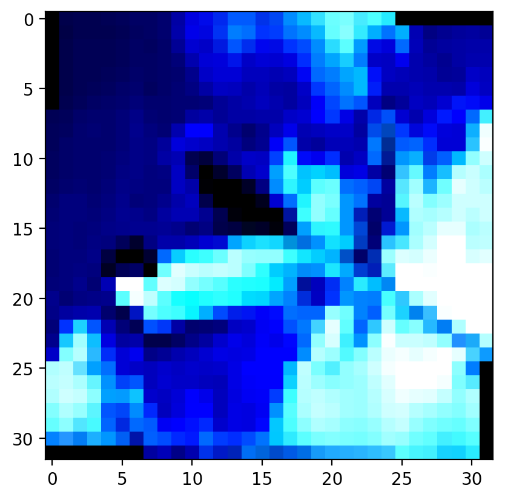

```
Clipping input data to the valid range for imshow with RGB data ([0..1] for floats or [0..255] for integers).
```

```
cat
```

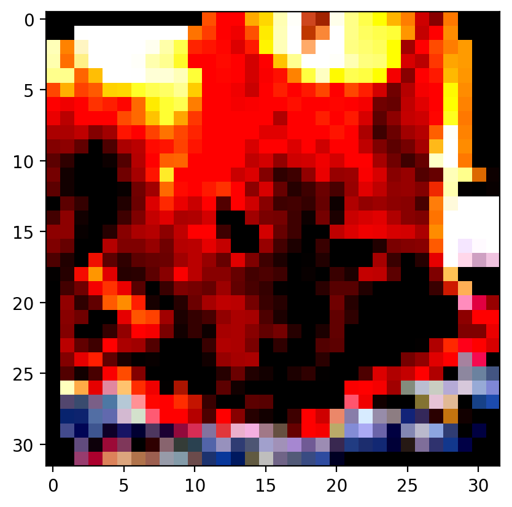

```
Clipping input data to the valid range for imshow with RGB data ([0..1] for floats or [0..255] for integers).
```

```
plane
```

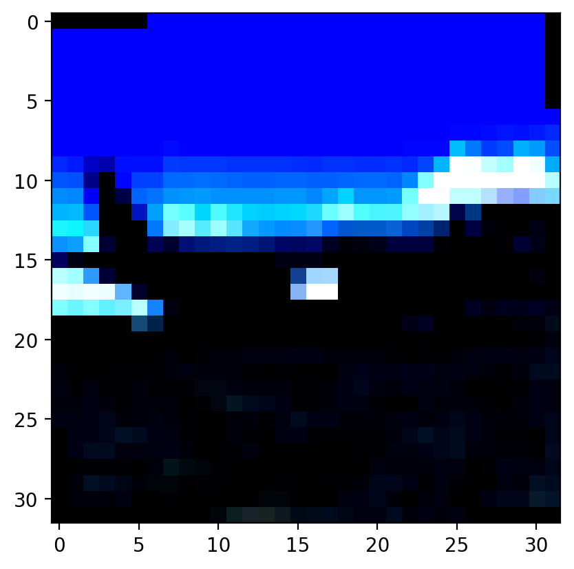

```
Clipping input data to the valid range for imshow with RGB data ([0..1] for floats or [0..255] for integers).
```

```
plane
```

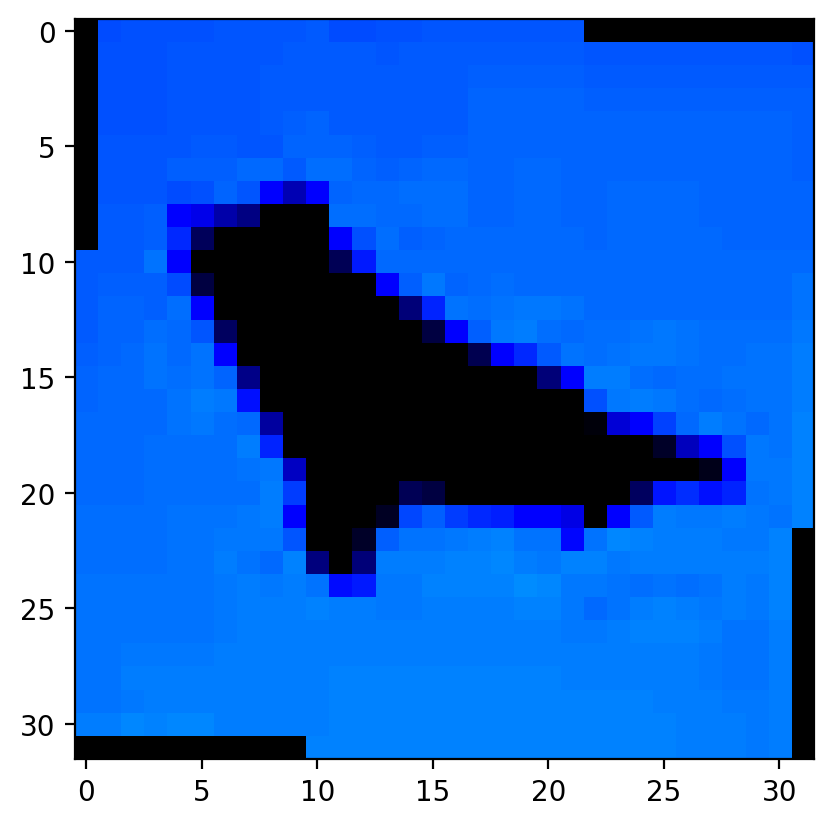

```
Clipping input data to the valid range for imshow with RGB data ([0..1] for floats or [0..255] for integers).
```

```
cat
```

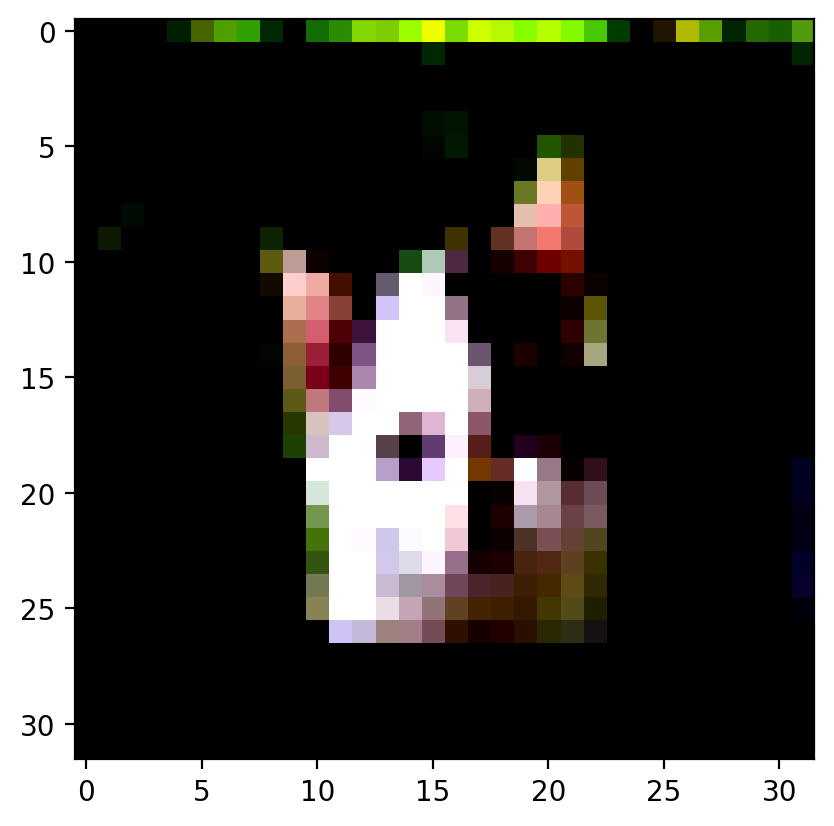

```python
# Explore data
## YOUR CODE HERE ##
dataiter = iter(trainloader)
images, labels = next(dataiter)

print(f"Dataset Summary:")
print(f"No of Samples in training dataset: {len(trainloader)}")
print(f"No of Samples in testing dataset: {len(testloader)}")
print(f"")
print(f"Shape of one batch of images: {images.shape}")  # Shape: (batch_size, channels, height, width)
print(f"Shape of one batch of labels: {labels.shape}")
print(f"")

# Plot the image
show5(dataiter)
```

## Build your Neural Network

Using the layers in `torch.nn` (which has been imported as `nn`) and the `torch.nn.functional` module (imported as `F`), construct a neural network based on the parameters of the dataset. Feel free to construct a model of any architecture – feedforward, convolutional, or even something more advanced!

```python
class Classifier(nn.Module):
    def __init__(self):
        super().__init__()
        self.conv1 = nn.Conv2d(3, 16, 3, padding=1)
        #self.bn1 = nn.BatchNorm2d(16)
        self.pool = nn.MaxPool2d(2, 2)
        self.conv2 = nn.Conv2d(16, 32, 3, padding=1)
        #self.bn2 = nn.BatchNorm2d(16)
        self.conv3 = nn.Conv2d(32, 64, 3, padding=1)
        #self.bn3 = nn.BatchNorm2d(16)

        # Calculate flattened size dynamically
        dummy_input = torch.zeros((1, 3, 32, 32))
        x = self.pool(F.relu(self.conv1(dummy_input)))
        x = self.pool(F.relu(self.conv2(x)))
        x = self.pool(F.relu(self.conv3(x)))
        flattened_size = x.numel()

        # Define fully connected layers with dropout
        self.fc1 = nn.Linear(flattened_size, 256)
        self.dropout = nn.Dropout(0.1)  # 10% drop
        self.fc2 = nn.Linear(256, 10)

    def forward(self, x):
        x = self.pool(F.relu(self.conv1(x)))
        x = self.pool(F.relu(self.conv2(x)))
        x = self.pool(F.relu(self.conv3(x)))
        x = torch.flatten(x, start_dim=1)
        x = F.relu(self.fc1(x))
        x = self.dropout(x)
        x = self.fc2(x)
        return x
```

Specify a loss function and an optimizer, and instantiate the model.

If you use a less common loss function, please note why you chose that loss function in a comment.

```python
## YOUR CODE HERE ##
model = Classifier()
criterion = nn.CrossEntropyLoss()  # Loss function for multi-class classification
optimizer = torch.optim.Adam(model.parameters(), lr=0.001)
```

## Running your Neural Network

Use whatever method you like to train your neural network, and ensure you record the average loss at each epoch. Don't forget to use `torch.device()` and the `.to()` method for both your model and your data if you are using GPU!

If you want to print your loss during each epoch, you can use the `enumerate` function and print the loss after a set number of batches. 250 batches works well for most people!

```python
# Move the model to the appropriate device
device = torch.device("cuda" if torch.cuda.is_available() else "cpu")
model.to(device)

# Set the number of epochs and initialize the optimizer and loss function
epochs = 5
train_losses, test_losses = [], []

# Training loop
for e in range(epochs):
    running_loss = 0
    model.train()  # Set the model to training mode

    for images, labels in trainloader:
        # Move images and labels to the device
        images, labels = images.to(device), labels.to(device)

        # Zero the gradients
        optimizer.zero_grad()

        # Forward pass
        log_ps = model(images)  # Output log probabilities

        # Compute loss
        loss = criterion(log_ps, labels)

        # Backward pass and optimization step
        loss.backward()
        optimizer.step()

        running_loss += loss.item()

    # Print average loss for the epoch
    print(f"Epoch {e+1}/{epochs}.. Training loss: {running_loss/len(trainloader):.3f}")

    # Track training loss for the epoch
    train_loss = running_loss / len(trainloader.dataset)
    train_losses.append(train_loss)


    # Validation loop
    model.eval()  # Set the model to evaluation mode
    tot_test_loss = 0
    test_correct = 0  # Number of correct predictions on the test set

    with torch.no_grad():
        for images, labels in valloader:
            # Move images and labels to the device
            images, labels = images.to(device), labels.to(device)

            # Forward pass
            log_ps = model(images)
            loss = criterion(log_ps, labels)
            tot_test_loss += loss.item()

            # Calculate accuracy
            ps = torch.exp(log_ps)  # Convert log probabilities to probabilities
            top_p, top_class = ps.topk(1, dim=1)
            equals = top_class == labels.view(*top_class.shape)
            test_correct += equals.sum().item()

    # Calculate average losses and accuracy
    test_loss = tot_test_loss / len(valloader.dataset)
    test_losses.append(test_loss)
    test_accuracy = test_correct / len(valloader.dataset)

    # Print metrics for the epoch
    print(f"Epoch {e+1}/{epochs}.. "
          f"Training Loss: {train_loss:.3f}.. "
          f"Test Loss: {test_loss:.3f}.. "
          f"Test Accuracy: {test_accuracy:.3f}")
```

[output not shown]

Plot the training loss (and validation loss/accuracy, if recorded).

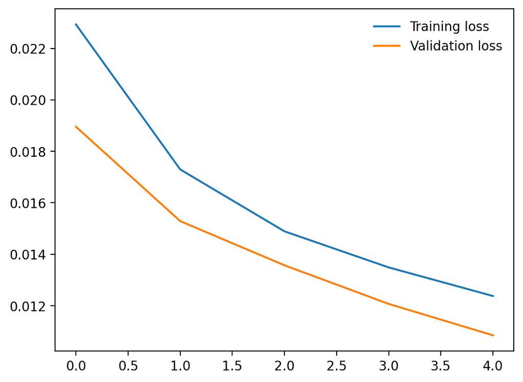

```python
## YOUR CODE HERE ##
%matplotlib inline
%config InlineBackend.figure_format = 'retina'

import matplotlib.pyplot as plt

plt.plot(train_losses, label='Training loss')
plt.plot(test_losses, label='Validation loss')
plt.legend(frameon=False)
```

## Testing your model

Using the previously created `DataLoader` for the test set, compute the percentage of correct predictions using the highest probability prediction.

If your accuracy is over 70%, great work! This is a hard task to exceed 70% on.

If your accuracy is under 45%, you'll need to make improvements. Go back and check your model architecture, loss function, and optimizer to make sure they're appropriate for an image classification task.

```python
## YOUR CODE HERE ##
correct = 0
total = 0
device = torch.device("cuda" if torch.cuda.is_available() else "cpu")
print(f"Using device: {device}")

# Set the model to evaluation mode
model.eval()

# Turn off gradients
with torch.no_grad():
    for images, labels in testloader:
        images, labels = images.to(device), labels.to(device)

        # Get model predictions
        log_ps = model(images)  # Log probabilities
        ps = torch.exp(log_ps)  # Convert to probabilities

        # Get the class with the highest probability
        top_p, top_class = ps.topk(1, dim=1)

        # Check if the predictions match the actual labels
        equals = top_class == labels.view(*top_class.shape)
        correct += equals.sum().item()
        total += labels.size(0)

# Calculate accuracy
accuracy = correct / total * 100
print(f"Accuracy on the test set: {accuracy:.2f}%")
```

```
Using device: cpu
Accuracy on the test set: 70.98%
```

```python
## Visualizing 1 image and the output class
```

```
Clipping input data to the valid range for imshow with RGB data ([0..1] for floats or [0..255] for integers).
```

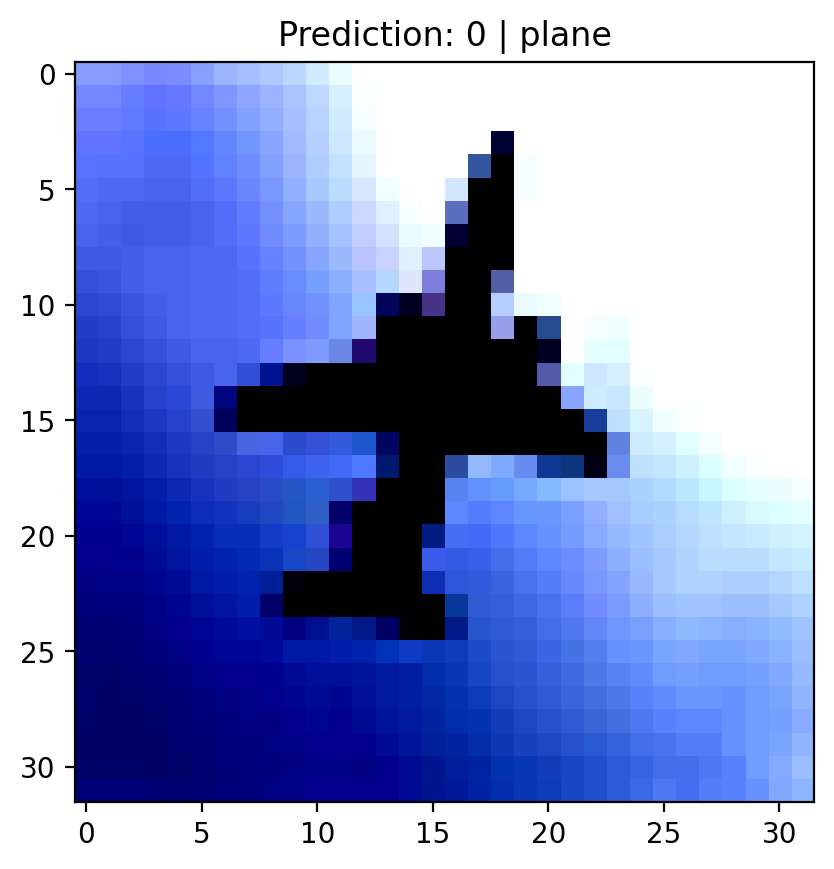

```python
%matplotlib inline

images, labels = next(iter(trainloader))
img = images[0]

# Set model to evaluation mode
model.eval()

# Turn off gradients for inference
with torch.no_grad():
    logps = model(img.unsqueeze(0).to(device))  # Add batch dimension and move to device

# Convert log-probabilities to probabilities
ps = torch.exp(logps)

# Helper function to display the image with its predicted class
def view_classify(img, ps):
    # Convert the tensor image to numpy for plotting
    img = img.numpy().transpose((1, 2, 0))  # Convert from (C, H, W) to (H, W, C)

    # Get the top predicted class and its probability
    top_p, top_class = ps.topk(1, dim=1)

    # Plotting the image
    plt.imshow(img)
    plt.title(f"Prediction: {top_class.item()} | {classes[top_class.item()]}")
    plt.show()

# Display the image with the predicted class and probability
view_classify(img, ps)
```

## Saving your model

Using `torch.save`, save your model for future loading.

```python
## YOUR CODE HERE ##

print("Our model: \n\n", model, '\n')
print("The state dict keys: \n\n", model.state_dict().keys())


# Save the model's state_dict
torch.save(model.state_dict(), 'checkpoint.pth')
print("Model saved successfully!")
```

```
Our model:

 Classifier(
  (conv1): Conv2d(3, 16, kernel_size=(3, 3), stride=(1, 1), padding=(1, 1))
  (pool): MaxPool2d(kernel_size=2, stride=2, padding=0, dilation=1, ceil_mode=False)
  (conv2): Conv2d(16, 32, kernel_size=(3, 3), stride=(1, 1), padding=(1, 1))
  (conv3): Conv2d(32, 64, kernel_size=(3, 3), stride=(1, 1), padding=(1, 1))
  (fc1): Linear(in_features=1024, out_features=256, bias=True)
  (dropout): Dropout(p=0.1, inplace=False)
  (fc2): Linear(in_features=256, out_features=10, bias=True)
)

The state dict keys:

 odict_keys(['conv1.weight', 'conv1.bias', 'conv2.weight', 'conv2.bias', 'conv3.weight', 'conv3.bias', 'fc1.weight', 'fc1.bias', 'fc2.weight', 'fc2.bias'])
Model saved successfully!
```

```python
# Loading the network
state_dict = torch.load('checkpoint.pth')
print(state_dict.keys())
```

```
odict_keys(['conv1.weight', 'conv1.bias', 'conv2.weight', 'conv2.bias', 'conv3.weight', 'conv3.bias', 'fc1.weight', 'fc1.bias', 'fc2.weight', 'fc2.bias'])
```

## Make a Recommendation

Based on your evaluation, what is your recommendation on whether to build or buy? Explain your reasoning below.

Some things to consider as you formulate your recommendation:

- How does your model compare to Detectocorp's model?
- How does it compare to the far more advanced solutions in the literature?
- What did you do to get the accuracy you achieved?
- Is it necessary to improve this accuracy? If so, what sort of work would be involved in improving it?

I recommend to **build** the model in-house as our model achieves an accuracy of 71%, surpassing Detectocorp's performance target of 70%.

**Comparison to Advanced Solutions:**

While advanced models such as Wide Residual Networks and Maxout Networks have the potential to outperform our model in terms of accuracy, they come with significantly increased complexity and computational requirements.

For CIFAR-10, our CNN model already provides a competitive balance of efficiency and performance.

**What Was Done to Achieve Current Accuracy:**

(i) We used three convolutional layers and appropriate pooling and fully connected layers.

(ii) Dropout was introduced to mitigate overfitting.

(iv) A suitable optimizer (Adam) and learning rate were selected, balancing convergence speed and stability

**Is Further Accuracy Improvement Necessary?**

Improving accuracy beyond 70% depends on the business need. If the task requires highly reliable predictions, further accuracy improvements are necessary. If the goal is cost-effectiveness while maintaining Detectocorp-level performance, the current solution is sufficient.

**Steps to Further Improve Accuracy:**

(i) Add additional augmentation techniques, such as color jitter or brightness adjustments

(ii) Use tools like Optuna or grid search to optimize learning rate, batch size, and dropout rate

(iii) Train for more epochs or use learning rate schedulers for gradual decay

## Submit Your Project

When you are finished editing the notebook and are ready to turn it in, simply click the **SUBMIT PROJECT** button in the lower right.

Once you submit your project, we'll review your work and give you feedback if there's anything that you need to work on. If you'd like to see the exact points that your reviewer will check for when looking at your work, you can have a look over the project [rubric](https://review.udacity.com/#!/rubrics/3077/view).